# Risk Factor Analysis

## Outcome Variable

**Outcome Variable:** y_rate_len

## Predictor Variables

**Intervention Variable:** predfeed3

**Adjustment Set:**

- arm
- sex
- month
- brthmon
- W_mage
- meducyrs
- feducyrs
- hhwealth_quart
- hfoodsec
- W_mhtcm
- vagbrth
- W_gagebrth
- W_birthwt
- W_birthlen
- W_nrooms
- W_nchldlt5
- W_parity
- impfloor
- impsan
- safeh20
- delta_W_mage
- delta_meducyrs
- delta_feducyrs
- delta_hhwealth_quart
- delta_hfoodsec
- delta_W_mhtcm
- delta_vagbrth
- delta_W_gagebrth
- delta_W_birthwt
- delta_W_birthlen
- delta_W_nrooms
- delta_W_nchldlt5
- delta_W_parity
- delta_impfloor
- delta_impsan
- delta_safeh20

## Stratifying Variables

The analysis was stratified on these variable(s):

- agecat
- studyid
- country

## Data Summary

| agecat | studyid | country | predfeed3 | n_cell | n |
| --- | --- | --- | --- | --- | --- |
| 0-3 months | ki0047075b-MAL-ED | BANGLADESH | 0 | 35 | 239 |
| 0-3 months | ki0047075b-MAL-ED | BANGLADESH | 1 | 204 | 239 |
| 0-3 months | ki0047075b-MAL-ED | BRAZIL | 0 | 80 | 180 |
| 0-3 months | ki0047075b-MAL-ED | BRAZIL | 1 | 100 | 180 |
| 0-3 months | ki0047075b-MAL-ED | INDIA | 0 | 46 | 199 |
| 0-3 months | ki0047075b-MAL-ED | INDIA | 1 | 153 | 199 |
| 0-3 months | ki0047075b-MAL-ED | NEPAL | 0 | 73 | 175 |
| 0-3 months | ki0047075b-MAL-ED | NEPAL | 1 | 102 | 175 |
| 0-3 months | ki0047075b-MAL-ED | PERU | 0 | 89 | 268 |
| 0-3 months | ki0047075b-MAL-ED | PERU | 1 | 179 | 268 |
| 0-3 months | ki0047075b-MAL-ED | SOUTH AFRICA | 0 | 140 | 226 |
| 0-3 months | ki0047075b-MAL-ED | SOUTH AFRICA | 1 | 86 | 226 |
| 0-3 months | ki0047075b-MAL-ED | TANZANIA, UNITED REPUBLIC OF | 0 | 145 | 224 |
| 0-3 months | ki0047075b-MAL-ED | TANZANIA, UNITED REPUBLIC OF | 1 | 79 | 224 |
| 0-3 months | ki1000109-EE | PAKISTAN | 0 | 32 | 592 |
| 0-3 months | ki1000109-EE | PAKISTAN | 1 | 560 | 592 |
| 0-3 months | kiGH5241-JiVitA-3 | BANGLADESH | 0 | 4246 | 39314 |
| 0-3 months | kiGH5241-JiVitA-3 | BANGLADESH | 1 | 35068 | 39314 |
| 0-3 months | kiGH5241-JiVitA-4 | BANGLADESH | 0 | 20 | 242 |
| 0-3 months | kiGH5241-JiVitA-4 | BANGLADESH | 1 | 222 | 242 |
| 3-6 months | ki0047075b-MAL-ED | BANGLADESH | 0 | 33 | 227 |
| 3-6 months | ki0047075b-MAL-ED | BANGLADESH | 1 | 194 | 227 |
| 3-6 months | ki0047075b-MAL-ED | BRAZIL | 0 | 92 | 208 |
| 3-6 months | ki0047075b-MAL-ED | BRAZIL | 1 | 116 | 208 |
| 3-6 months | ki0047075b-MAL-ED | INDIA | 0 | 53 | 229 |
| 3-6 months | ki0047075b-MAL-ED | INDIA | 1 | 176 | 229 |
| 3-6 months | ki0047075b-MAL-ED | NEPAL | 0 | 101 | 232 |
| 3-6 months | ki0047075b-MAL-ED | NEPAL | 1 | 131 | 232 |
| 3-6 months | ki0047075b-MAL-ED | PERU | 0 | 84 | 265 |
| 3-6 months | ki0047075b-MAL-ED | PERU | 1 | 181 | 265 |

[output cut: 54 more lines]

The following strata were considered:

- agecat: 0-3 months, studyid: ki0047075b-MAL-ED, country: BANGLADESH
- agecat: 0-3 months, studyid: ki0047075b-MAL-ED, country: BRAZIL
- agecat: 0-3 months, studyid: ki0047075b-MAL-ED, country: INDIA
- agecat: 0-3 months, studyid: ki0047075b-MAL-ED, country: NEPAL
- agecat: 0-3 months, studyid: ki0047075b-MAL-ED, country: PERU
- agecat: 0-3 months, studyid: ki0047075b-MAL-ED, country: SOUTH AFRICA
- agecat: 0-3 months, studyid: ki0047075b-MAL-ED, country: TANZANIA, UNITED REPUBLIC OF
- agecat: 0-3 months, studyid: ki1000109-EE, country: PAKISTAN
- agecat: 0-3 months, studyid: kiGH5241-JiVitA-3, country: BANGLADESH
- agecat: 0-3 months, studyid: kiGH5241-JiVitA-4, country: BANGLADESH
- agecat: 12-24 months, studyid: ki0047075b-MAL-ED, country: BANGLADESH
- agecat: 12-24 months, studyid: ki0047075b-MAL-ED, country: BRAZIL
- agecat: 12-24 months, studyid: ki0047075b-MAL-ED, country: INDIA
- agecat: 12-24 months, studyid: ki0047075b-MAL-ED, country: NEPAL
- agecat: 12-24 months, studyid: ki0047075b-MAL-ED, country: PERU
- agecat: 12-24 months, studyid: ki0047075b-MAL-ED, country: SOUTH AFRICA
- agecat: 12-24 months, studyid: ki0047075b-MAL-ED, country: TANZANIA, UNITED REPUBLIC OF
- agecat: 12-24 months, studyid: ki1113344-GMS-Nepal, country: NEPAL
- agecat: 12-24 months, studyid: kiGH5241-JiVitA-3, country: BANGLADESH
- agecat: 12-24 months, studyid: kiGH5241-JiVitA-4, country: BANGLADESH
- agecat: 3-6 months, studyid: ki0047075b-MAL-ED, country: BANGLADESH
- agecat: 3-6 months, studyid: ki0047075b-MAL-ED, country: BRAZIL
- agecat: 3-6 months, studyid: ki0047075b-MAL-ED, country: INDIA
- agecat: 3-6 months, studyid: ki0047075b-MAL-ED, country: NEPAL
- agecat: 3-6 months, studyid: ki0047075b-MAL-ED, country: PERU
- agecat: 3-6 months, studyid: ki0047075b-MAL-ED, country: SOUTH AFRICA
- agecat: 3-6 months, studyid: ki0047075b-MAL-ED, country: TANZANIA, UNITED REPUBLIC OF
- agecat: 3-6 months, studyid: ki1000109-EE, country: PAKISTAN
- agecat: 3-6 months, studyid: ki1113344-GMS-Nepal, country: NEPAL
- agecat: 3-6 months, studyid: kiGH5241-JiVitA-3, country: BANGLADESH
- agecat: 3-6 months, studyid: kiGH5241-JiVitA-4, country: BANGLADESH
- agecat: 6-12 months, studyid: ki0047075b-MAL-ED, country: BANGLADESH
- agecat: 6-12 months, studyid: ki0047075b-MAL-ED, country: BRAZIL
- agecat: 6-12 months, studyid: ki0047075b-MAL-ED, country: INDIA
- agecat: 6-12 months, studyid: ki0047075b-MAL-ED, country: NEPAL
- agecat: 6-12 months, studyid: ki0047075b-MAL-ED, country: PERU
- agecat: 6-12 months, studyid: ki0047075b-MAL-ED, country: SOUTH AFRICA
- agecat: 6-12 months, studyid: ki0047075b-MAL-ED, country: TANZANIA, UNITED REPUBLIC OF
- agecat: 6-12 months, studyid: ki1000109-EE, country: PAKISTAN
- agecat: 6-12 months, studyid: ki1113344-GMS-Nepal, country: NEPAL
- agecat: 6-12 months, studyid: kiGH5241-JiVitA-3, country: BANGLADESH
- agecat: 6-12 months, studyid: kiGH5241-JiVitA-4, country: BANGLADESH

### Dropped Strata

Some strata were dropped due to rare outcomes:

- agecat: 3-6 months, studyid: kiGH5241-JiVitA-4, country: BANGLADESH
- agecat: 6-12 months, studyid: ki1000109-EE, country: PAKISTAN
- agecat: 6-12 months, studyid: kiGH5241-JiVitA-4, country: BANGLADESH

## Methods Detail

We’re interested in the causal parameters $E[Y_a]$ for all values of $a \in \mathcal{A}$. These parameters represent the mean outcome if, possibly contrary to fact, we intervened to set all units to have $A=a$. Under the randomization and positivity assumptions, these are identified by the statistical parameters $\psi_a=E_W[E_{Y|A,W}(Y|A=a,W)]$. In addition, we’re interested in the mean of $Y$, $E[Y]$ under no intervention (the observed mean). We will estimate these parameters by using SuperLearner to fit the relevant likelihood factors – $E_{Y|A,W}(Y|A=a,W)$ and $p(A=a|W)$, and then updating our likelihood fit using a joint TMLE.

For unadjusted analyses ($W=\{\}$), initial likelihoods were estimated using Lrnr_glm to estimate the simple $E(Y|A)$ and Lrnr_mean to estimate $p(A)$. For adjusted analyses, a small library containing Lrnr_glmnet, Lrnr_xgboost, and Lrnr_mean was used.

Having estimated these parameters, we will then use the delta method to estimate relative risks and attributable risks relative to a prespecified baseline level of $A$.

# Results Detail

## Results Plots

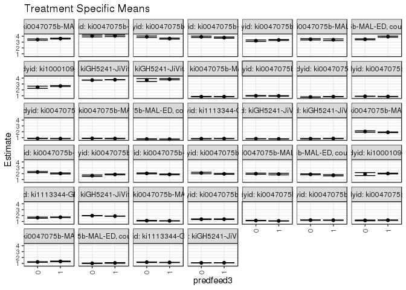

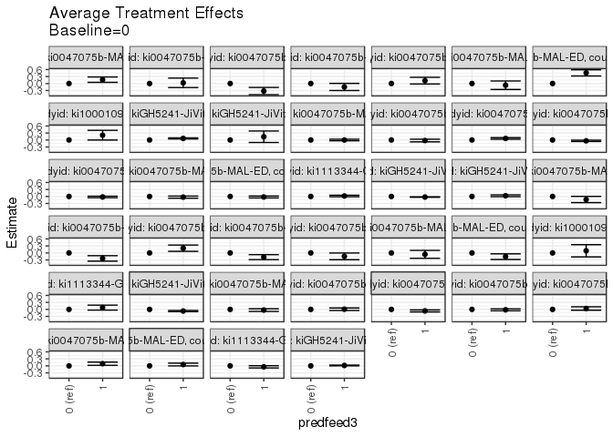

## Results Table

### Parameter: TSM

| agecat | studyid | country | intervention_level | baseline_level | estimate | ci_lower | ci_upper |
| --- | --- | --- | --- | --- | --- | --- | --- |
| 0-3 months | ki0047075b-MAL-ED | BANGLADESH | 0 | NA | 3.4277461 | 3.3165994 | 3.5388927 |
| 0-3 months | ki0047075b-MAL-ED | BANGLADESH | 1 | NA | 3.5924992 | 3.5269493 | 3.6580491 |
| 0-3 months | ki0047075b-MAL-ED | BRAZIL | 0 | NA | 4.0344846 | 3.8812504 | 4.1877189 |
| 0-3 months | ki0047075b-MAL-ED | BRAZIL | 1 | NA | 4.0641706 | 3.9295104 | 4.1988308 |
| 0-3 months | ki0047075b-MAL-ED | INDIA | 0 | NA | 3.9177715 | 3.7906977 | 4.0448452 |
| 0-3 months | ki0047075b-MAL-ED | INDIA | 1 | NA | 3.5951006 | 3.5095223 | 3.6806789 |
| 0-3 months | ki0047075b-MAL-ED | NEPAL | 0 | NA | 3.9064737 | 3.7874168 | 4.0255306 |
| 0-3 months | ki0047075b-MAL-ED | NEPAL | 1 | NA | 3.7589673 | 3.6624770 | 3.8554576 |
| 0-3 months | ki0047075b-MAL-ED | PERU | 0 | NA | 3.2344034 | 3.1113222 | 3.3574846 |
| 0-3 months | ki0047075b-MAL-ED | PERU | 1 | NA | 3.3580193 | 3.2855866 | 3.4304520 |
| 0-3 months | ki0047075b-MAL-ED | SOUTH AFRICA | 0 | NA | 3.4728433 | 3.3568257 | 3.5888610 |
| 0-3 months | ki0047075b-MAL-ED | SOUTH AFRICA | 1 | NA | 3.3994612 | 3.2592633 | 3.5396591 |
| 0-3 months | ki0047075b-MAL-ED | TANZANIA, UNITED REPUBLIC OF | 0 | NA | 3.4765438 | 3.3858561 | 3.5672316 |
| 0-3 months | ki0047075b-MAL-ED | TANZANIA, UNITED REPUBLIC OF | 1 | NA | 3.9325539 | 3.8354599 | 4.0296479 |
| 0-3 months | ki1000109-EE | PAKISTAN | 0 | NA | 2.4474650 | 2.2582632 | 2.6366669 |
| 0-3 months | ki1000109-EE | PAKISTAN | 1 | NA | 2.6534549 | 2.5668204 | 2.7400894 |
| 0-3 months | kiGH5241-JiVitA-3 | BANGLADESH | 0 | NA | 3.6633183 | 3.6415306 | 3.6851060 |
| 0-3 months | kiGH5241-JiVitA-3 | BANGLADESH | 1 | NA | 3.7311701 | 3.7204969 | 3.7418434 |
| 0-3 months | kiGH5241-JiVitA-4 | BANGLADESH | 0 | NA | 3.6698323 | 3.4271225 | 3.9125422 |
| 0-3 months | kiGH5241-JiVitA-4 | BANGLADESH | 1 | NA | 3.8090393 | 3.7098102 | 3.9082684 |
| 3-6 months | ki0047075b-MAL-ED | BANGLADESH | 0 | NA | 2.0444738 | 1.9224005 | 2.1665471 |
| 3-6 months | ki0047075b-MAL-ED | BANGLADESH | 1 | NA | 1.9143097 | 1.8609542 | 1.9676652 |
| 3-6 months | ki0047075b-MAL-ED | BRAZIL | 0 | NA | 2.2792700 | 2.1821181 | 2.3764219 |
| 3-6 months | ki0047075b-MAL-ED | BRAZIL | 1 | NA | 2.0433045 | 1.9583001 | 2.1283089 |
| 3-6 months | ki0047075b-MAL-ED | INDIA | 0 | NA | 1.6662382 | 1.5493644 | 1.7831120 |
| 3-6 months | ki0047075b-MAL-ED | INDIA | 1 | NA | 1.8687601 | 1.8032260 | 1.9342942 |
| 3-6 months | ki0047075b-MAL-ED | NEPAL | 0 | NA | 2.0535303 | 1.9712501 | 2.1358105 |
| 3-6 months | ki0047075b-MAL-ED | NEPAL | 1 | NA | 1.8727484 | 1.8046035 | 1.9408933 |
| 3-6 months | ki0047075b-MAL-ED | PERU | 0 | NA | 2.1207110 | 1.9987779 | 2.2426441 |
| 3-6 months | ki0047075b-MAL-ED | PERU | 1 | NA | 1.9737403 | 1.8965206 | 2.0509600 |
| 3-6 months | ki0047075b-MAL-ED | SOUTH AFRICA | 0 | NA | 1.9978800 | 1.8969163 | 2.0988438 |
| 3-6 months | ki0047075b-MAL-ED | SOUTH AFRICA | 1 | NA | 1.9376178 | 1.8014237 | 2.0738120 |
| 3-6 months | ki0047075b-MAL-ED | TANZANIA, UNITED REPUBLIC OF | 0 | NA | 1.8880705 | 1.8057621 | 1.9703788 |
| 3-6 months | ki0047075b-MAL-ED | TANZANIA, UNITED REPUBLIC OF | 1 | NA | 1.7287774 | 1.6297740 | 1.8277807 |
| 3-6 months | ki1000109-EE | PAKISTAN | 0 | NA | 1.9392571 | 1.6840887 | 2.1944254 |
| 3-6 months | ki1000109-EE | PAKISTAN | 1 | NA | 2.0313873 | 1.9690533 | 2.0937212 |
| 3-6 months | ki1113344-GMS-Nepal | NEPAL | 0 | NA | 1.6422563 | 1.5444343 | 1.7400783 |
| 3-6 months | ki1113344-GMS-Nepal | NEPAL | 1 | NA | 1.7186510 | 1.6740844 | 1.7632175 |
| 3-6 months | kiGH5241-JiVitA-3 | BANGLADESH | 0 | NA | 1.9822278 | 1.9591464 | 2.0053093 |
| 3-6 months | kiGH5241-JiVitA-3 | BANGLADESH | 1 | NA | 1.9121197 | 1.9014117 | 1.9228277 |
| 6-12 months | ki0047075b-MAL-ED | BANGLADESH | 0 | NA | 1.1381378 | 1.0836316 | 1.1926440 |
| 6-12 months | ki0047075b-MAL-ED | BANGLADESH | 1 | NA | 1.1097416 | 1.0840593 | 1.1354239 |
| 6-12 months | ki0047075b-MAL-ED | BRAZIL | 0 | NA | 1.3818022 | 1.3233048 | 1.4402997 |
| 6-12 months | ki0047075b-MAL-ED | BRAZIL | 1 | NA | 1.3891853 | 1.3406796 | 1.4376910 |
| 6-12 months | ki0047075b-MAL-ED | INDIA | 0 | NA | 1.1602214 | 1.1216037 | 1.1988390 |
| 6-12 months | ki0047075b-MAL-ED | INDIA | 1 | NA | 1.0960589 | 1.0673479 | 1.1247699 |
| 6-12 months | ki0047075b-MAL-ED | NEPAL | 0 | NA | 1.2325712 | 1.1971740 | 1.2679685 |
| 6-12 months | ki0047075b-MAL-ED | NEPAL | 1 | NA | 1.2151576 | 1.1842751 | 1.2460400 |
| 6-12 months | ki0047075b-MAL-ED | PERU | 0 | NA | 1.1829568 | 1.1205519 | 1.2453617 |
| 6-12 months | ki0047075b-MAL-ED | PERU | 1 | NA | 1.2216366 | 1.1832614 | 1.2600119 |
| 6-12 months | ki0047075b-MAL-ED | SOUTH AFRICA | 0 | NA | 1.2369277 | 1.1877744 | 1.2860810 |
| 6-12 months | ki0047075b-MAL-ED | SOUTH AFRICA | 1 | NA | 1.3302289 | 1.2714795 | 1.3889784 |
| 6-12 months | ki0047075b-MAL-ED | TANZANIA, UNITED REPUBLIC OF | 0 | NA | 1.0168654 | 0.9754181 | 1.0583127 |
| 6-12 months | ki0047075b-MAL-ED | TANZANIA, UNITED REPUBLIC OF | 1 | NA | 1.0745517 | 1.0200165 | 1.1290869 |
| 6-12 months | ki1113344-GMS-Nepal | NEPAL | 0 | NA | 1.1980080 | 1.1550893 | 1.2409267 |
| 6-12 months | ki1113344-GMS-Nepal | NEPAL | 1 | NA | 1.1560528 | 1.1317852 | 1.1803203 |
| 6-12 months | kiGH5241-JiVitA-3 | BANGLADESH | 0 | NA | 1.0883433 | 1.0729291 | 1.1037575 |
| 6-12 months | kiGH5241-JiVitA-3 | BANGLADESH | 1 | NA | 1.1060095 | 1.0990252 | 1.1129939 |
| 12-24 months | ki0047075b-MAL-ED | BANGLADESH | 0 | NA | 0.8457295 | 0.8129842 | 0.8784748 |
| 12-24 months | ki0047075b-MAL-ED | BANGLADESH | 1 | NA | 0.8455234 | 0.8287706 | 0.8622762 |
| 12-24 months | ki0047075b-MAL-ED | BRAZIL | 0 | NA | 0.9948011 | 0.9526147 | 1.0369875 |
| 12-24 months | ki0047075b-MAL-ED | BRAZIL | 1 | NA | 0.9721530 | 0.9311130 | 1.0131929 |
| 12-24 months | ki0047075b-MAL-ED | INDIA | 0 | NA | 0.7813520 | 0.7541352 | 0.8085689 |
| 12-24 months | ki0047075b-MAL-ED | INDIA | 1 | NA | 0.8469600 | 0.8270887 | 0.8668314 |
| 12-24 months | ki0047075b-MAL-ED | NEPAL | 0 | NA | 0.9047569 | 0.8840727 | 0.9254410 |
| 12-24 months | ki0047075b-MAL-ED | NEPAL | 1 | NA | 0.8685804 | 0.8504901 | 0.8866706 |
| 12-24 months | ki0047075b-MAL-ED | PERU | 0 | NA | 0.8614649 | 0.8306804 | 0.8922493 |
| 12-24 months | ki0047075b-MAL-ED | PERU | 1 | NA | 0.8405906 | 0.8187262 | 0.8624550 |
| 12-24 months | ki0047075b-MAL-ED | SOUTH AFRICA | 0 | NA | 0.8808888 | 0.8520683 | 0.9097093 |
| 12-24 months | ki0047075b-MAL-ED | SOUTH AFRICA | 1 | NA | 0.8528162 | 0.8175509 | 0.8880815 |
| 12-24 months | ki0047075b-MAL-ED | TANZANIA, UNITED REPUBLIC OF | 0 | NA | 0.7614849 | 0.7313607 | 0.7916090 |
| 12-24 months | ki0047075b-MAL-ED | TANZANIA, UNITED REPUBLIC OF | 1 | NA | 0.7402521 | 0.7088934 | 0.7716107 |
| 12-24 months | ki1113344-GMS-Nepal | NEPAL | 0 | NA | 0.8197256 | 0.7911888 | 0.8482624 |
| 12-24 months | ki1113344-GMS-Nepal | NEPAL | 1 | NA | 0.8398662 | 0.8216869 | 0.8580456 |
| 12-24 months | kiGH5241-JiVitA-3 | BANGLADESH | 0 | NA | 0.8191010 | 0.8094982 | 0.8287037 |
| 12-24 months | kiGH5241-JiVitA-3 | BANGLADESH | 1 | NA | 0.7938924 | 0.7883493 | 0.7994356 |
| 12-24 months | kiGH5241-JiVitA-4 | BANGLADESH | 0 | NA | 0.8202136 | 0.7873366 | 0.8530906 |
| 12-24 months | kiGH5241-JiVitA-4 | BANGLADESH | 1 | NA | 0.8501841 | 0.8266174 | 0.8737509 |

### Parameter: E(Y)

| agecat | studyid | country | intervention_level | baseline_level | estimate | ci_lower | ci_upper |
| --- | --- | --- | --- | --- | --- | --- | --- |
| 0-3 months | ki0047075b-MAL-ED | BANGLADESH | NA | NA | 3.5678222 | 3.5043711 | 3.6312732 |
| 0-3 months | ki0047075b-MAL-ED | BRAZIL | NA | NA | 4.0509714 | 3.9492443 | 4.1526985 |
| 0-3 months | ki0047075b-MAL-ED | INDIA | NA | NA | 3.5659922 | 3.4894688 | 3.6425155 |
| 0-3 months | ki0047075b-MAL-ED | NEPAL | NA | NA | 3.8204935 | 3.7444190 | 3.8965681 |
| 0-3 months | ki0047075b-MAL-ED | PERU | NA | NA | 3.3169678 | 3.2532502 | 3.3806854 |
| 0-3 months | ki0047075b-MAL-ED | SOUTH AFRICA | NA | NA | 3.4449056 | 3.3547788 | 3.5350324 |
| 0-3 months | ki0047075b-MAL-ED | TANZANIA, UNITED REPUBLIC OF | NA | NA | 3.4805903 | 3.4021811 | 3.5589994 |
| 0-3 months | ki1000109-EE | PAKISTAN | NA | NA | 2.6551376 | 2.5714235 | 2.7388517 |
| 0-3 months | kiGH5241-JiVitA-3 | BANGLADESH | NA | NA | 3.7192245 | 3.7088675 | 3.7295816 |
| 0-3 months | kiGH5241-JiVitA-4 | BANGLADESH | NA | NA | 3.7971810 | 3.7001091 | 3.8942529 |
| 3-6 months | ki0047075b-MAL-ED | BANGLADESH | NA | NA | 1.9332346 | 1.8839439 | 1.9825252 |
| 3-6 months | ki0047075b-MAL-ED | BRAZIL | NA | NA | 2.1478156 | 2.0686357 | 2.2269955 |
| 3-6 months | ki0047075b-MAL-ED | INDIA | NA | NA | 1.8837264 | 1.8224393 | 1.9450135 |
| 3-6 months | ki0047075b-MAL-ED | NEPAL | NA | NA | 1.9656096 | 1.9095163 | 2.0217030 |
| 3-6 months | ki0047075b-MAL-ED | PERU | NA | NA | 2.0203240 | 1.9541588 | 2.0864891 |
| 3-6 months | ki0047075b-MAL-ED | SOUTH AFRICA | NA | NA | 1.9760831 | 1.8948819 | 2.0572842 |
| 3-6 months | ki0047075b-MAL-ED | TANZANIA, UNITED REPUBLIC OF | NA | NA | 1.8266539 | 1.7572406 | 1.8960671 |
| 3-6 months | ki1000109-EE | PAKISTAN | NA | NA | 2.0252445 | 1.9646316 | 2.0858574 |
| 3-6 months | ki1113344-GMS-Nepal | NEPAL | NA | NA | 1.7053522 | 1.6641174 | 1.7465871 |
| 3-6 months | kiGH5241-JiVitA-3 | BANGLADESH | NA | NA | 1.9187609 | 1.9082629 | 1.9292589 |
| 6-12 months | ki0047075b-MAL-ED | BANGLADESH | NA | NA | 1.1145925 | 1.0894523 | 1.1397328 |
| 6-12 months | ki0047075b-MAL-ED | BRAZIL | NA | NA | 1.3863464 | 1.3400121 | 1.4326807 |
| 6-12 months | ki0047075b-MAL-ED | INDIA | NA | NA | 1.1209771 | 1.0924290 | 1.1495253 |
| 6-12 months | ki0047075b-MAL-ED | NEPAL | NA | NA | 1.2232375 | 1.1973421 | 1.2491328 |
| 6-12 months | ki0047075b-MAL-ED | PERU | NA | NA | 1.2098360 | 1.1769906 | 1.2426814 |
| 6-12 months | ki0047075b-MAL-ED | SOUTH AFRICA | NA | NA | 1.1945255 | 1.1527026 | 1.2363484 |
| 6-12 months | ki0047075b-MAL-ED | TANZANIA, UNITED REPUBLIC OF | NA | NA | 1.0005581 | 0.9627597 | 1.0383564 |
| 6-12 months | ki1113344-GMS-Nepal | NEPAL | NA | NA | 1.1629820 | 1.1410485 | 1.1849155 |
| 6-12 months | kiGH5241-JiVitA-3 | BANGLADESH | NA | NA | 1.1059670 | 1.0990549 | 1.1128791 |
| 12-24 months | ki0047075b-MAL-ED | BANGLADESH | NA | NA | 0.8451111 | 0.8289738 | 0.8612484 |
| 12-24 months | ki0047075b-MAL-ED | BRAZIL | NA | NA | 0.9816245 | 0.9508764 | 1.0123725 |
| 12-24 months | ki0047075b-MAL-ED | INDIA | NA | NA | 0.8811230 | 0.8637093 | 0.8985366 |
| 12-24 months | ki0047075b-MAL-ED | NEPAL | NA | NA | 0.8619667 | 0.8466720 | 0.8772613 |
| 12-24 months | ki0047075b-MAL-ED | PERU | NA | NA | 0.8468739 | 0.8260907 | 0.8676570 |
| 12-24 months | ki0047075b-MAL-ED | SOUTH AFRICA | NA | NA | 0.8711135 | 0.8486025 | 0.8936245 |
| 12-24 months | ki0047075b-MAL-ED | TANZANIA, UNITED REPUBLIC OF | NA | NA | 0.7650096 | 0.7411815 | 0.7888377 |
| 12-24 months | ki1113344-GMS-Nepal | NEPAL | NA | NA | 0.8364607 | 0.8197402 | 0.8531812 |
| 12-24 months | kiGH5241-JiVitA-3 | BANGLADESH | NA | NA | 0.7963475 | 0.7909428 | 0.8017521 |
| 12-24 months | kiGH5241-JiVitA-4 | BANGLADESH | NA | NA | 0.8491878 | 0.8267526 | 0.8716231 |

### Parameter: ATE

| agecat | studyid | country | intervention_level | baseline_level | estimate | ci_lower | ci_upper |
| --- | --- | --- | --- | --- | --- | --- | --- |
| 0-3 months | ki0047075b-MAL-ED | BANGLADESH | 0 | 0 | 0.0000000 | 0.0000000 | 0.0000000 |
| 0-3 months | ki0047075b-MAL-ED | BANGLADESH | 1 | 0 | 0.1647531 | 0.0495921 | 0.2799141 |
| 0-3 months | ki0047075b-MAL-ED | BRAZIL | 0 | 0 | 0.0000000 | 0.0000000 | 0.0000000 |
| 0-3 months | ki0047075b-MAL-ED | BRAZIL | 1 | 0 | 0.0296860 | -0.1732773 | 0.2326493 |
| 0-3 months | ki0047075b-MAL-ED | INDIA | 0 | 0 | 0.0000000 | 0.0000000 | 0.0000000 |
| 0-3 months | ki0047075b-MAL-ED | INDIA | 1 | 0 | -0.3226709 | -0.4773199 | -0.1680218 |
| 0-3 months | ki0047075b-MAL-ED | NEPAL | 0 | 0 | 0.0000000 | 0.0000000 | 0.0000000 |
| 0-3 months | ki0047075b-MAL-ED | NEPAL | 1 | 0 | -0.1475064 | -0.3002220 | 0.0052091 |
| 0-3 months | ki0047075b-MAL-ED | PERU | 0 | 0 | 0.0000000 | 0.0000000 | 0.0000000 |
| 0-3 months | ki0047075b-MAL-ED | PERU | 1 | 0 | 0.1236159 | -0.0191968 | 0.2664287 |
| 0-3 months | ki0047075b-MAL-ED | SOUTH AFRICA | 0 | 0 | 0.0000000 | 0.0000000 | 0.0000000 |
| 0-3 months | ki0047075b-MAL-ED | SOUTH AFRICA | 1 | 0 | -0.0733822 | -0.2543026 | 0.1075383 |
| 0-3 months | ki0047075b-MAL-ED | TANZANIA, UNITED REPUBLIC OF | 0 | 0 | 0.0000000 | 0.0000000 | 0.0000000 |
| 0-3 months | ki0047075b-MAL-ED | TANZANIA, UNITED REPUBLIC OF | 1 | 0 | 0.4560100 | 0.3238577 | 0.5881624 |
| 0-3 months | ki1000109-EE | PAKISTAN | 0 | 0 | 0.0000000 | 0.0000000 | 0.0000000 |
| 0-3 months | ki1000109-EE | PAKISTAN | 1 | 0 | 0.2059899 | -0.0011651 | 0.4131449 |
| 0-3 months | kiGH5241-JiVitA-3 | BANGLADESH | 0 | 0 | 0.0000000 | 0.0000000 | 0.0000000 |
| 0-3 months | kiGH5241-JiVitA-3 | BANGLADESH | 1 | 0 | 0.0678518 | 0.0447029 | 0.0910008 |
| 0-3 months | kiGH5241-JiVitA-4 | BANGLADESH | 0 | 0 | 0.0000000 | 0.0000000 | 0.0000000 |
| 0-3 months | kiGH5241-JiVitA-4 | BANGLADESH | 1 | 0 | 0.1392070 | -0.1066878 | 0.3851017 |
| 3-6 months | ki0047075b-MAL-ED | BANGLADESH | 0 | 0 | 0.0000000 | 0.0000000 | 0.0000000 |
| 3-6 months | ki0047075b-MAL-ED | BANGLADESH | 1 | 0 | -0.1301641 | -0.2634359 | 0.0031077 |
| 3-6 months | ki0047075b-MAL-ED | BRAZIL | 0 | 0 | 0.0000000 | 0.0000000 | 0.0000000 |
| 3-6 months | ki0047075b-MAL-ED | BRAZIL | 1 | 0 | -0.2359655 | -0.3534058 | -0.1185252 |
| 3-6 months | ki0047075b-MAL-ED | INDIA | 0 | 0 | 0.0000000 | 0.0000000 | 0.0000000 |
| 3-6 months | ki0047075b-MAL-ED | INDIA | 1 | 0 | 0.2025219 | 0.0680767 | 0.3369671 |
| 3-6 months | ki0047075b-MAL-ED | NEPAL | 0 | 0 | 0.0000000 | 0.0000000 | 0.0000000 |
| 3-6 months | ki0047075b-MAL-ED | NEPAL | 1 | 0 | -0.1807819 | -0.2874244 | -0.0741395 |
| 3-6 months | ki0047075b-MAL-ED | PERU | 0 | 0 | 0.0000000 | 0.0000000 | 0.0000000 |
| 3-6 months | ki0047075b-MAL-ED | PERU | 1 | 0 | -0.1469707 | -0.2907267 | -0.0032146 |
| 3-6 months | ki0047075b-MAL-ED | SOUTH AFRICA | 0 | 0 | 0.0000000 | 0.0000000 | 0.0000000 |
| 3-6 months | ki0047075b-MAL-ED | SOUTH AFRICA | 1 | 0 | -0.0602622 | -0.2297984 | 0.1092740 |
| 3-6 months | ki0047075b-MAL-ED | TANZANIA, UNITED REPUBLIC OF | 0 | 0 | 0.0000000 | 0.0000000 | 0.0000000 |
| 3-6 months | ki0047075b-MAL-ED | TANZANIA, UNITED REPUBLIC OF | 1 | 0 | -0.1592931 | -0.2801364 | -0.0384498 |
| 3-6 months | ki1000109-EE | PAKISTAN | 0 | 0 | 0.0000000 | 0.0000000 | 0.0000000 |
| 3-6 months | ki1000109-EE | PAKISTAN | 1 | 0 | 0.0921302 | -0.1707279 | 0.3549882 |
| 3-6 months | ki1113344-GMS-Nepal | NEPAL | 0 | 0 | 0.0000000 | 0.0000000 | 0.0000000 |
| 3-6 months | ki1113344-GMS-Nepal | NEPAL | 1 | 0 | 0.0763947 | -0.0300051 | 0.1827945 |
| 3-6 months | kiGH5241-JiVitA-3 | BANGLADESH | 0 | 0 | 0.0000000 | 0.0000000 | 0.0000000 |
| 3-6 months | kiGH5241-JiVitA-3 | BANGLADESH | 1 | 0 | -0.0701081 | -0.0944712 | -0.0457450 |
| 6-12 months | ki0047075b-MAL-ED | BANGLADESH | 0 | 0 | 0.0000000 | 0.0000000 | 0.0000000 |
| 6-12 months | ki0047075b-MAL-ED | BANGLADESH | 1 | 0 | -0.0283962 | -0.0845697 | 0.0277774 |
| 6-12 months | ki0047075b-MAL-ED | BRAZIL | 0 | 0 | 0.0000000 | 0.0000000 | 0.0000000 |
| 6-12 months | ki0047075b-MAL-ED | BRAZIL | 1 | 0 | 0.0073830 | -0.0464795 | 0.0612456 |
| 6-12 months | ki0047075b-MAL-ED | INDIA | 0 | 0 | 0.0000000 | 0.0000000 | 0.0000000 |
| 6-12 months | ki0047075b-MAL-ED | INDIA | 1 | 0 | -0.0641625 | -0.1071134 | -0.0212116 |
| 6-12 months | ki0047075b-MAL-ED | NEPAL | 0 | 0 | 0.0000000 | 0.0000000 | 0.0000000 |
| 6-12 months | ki0047075b-MAL-ED | NEPAL | 1 | 0 | -0.0174137 | -0.0593061 | 0.0244788 |
| 6-12 months | ki0047075b-MAL-ED | PERU | 0 | 0 | 0.0000000 | 0.0000000 | 0.0000000 |
| 6-12 months | ki0047075b-MAL-ED | PERU | 1 | 0 | 0.0386798 | -0.0345802 | 0.1119399 |
| 6-12 months | ki0047075b-MAL-ED | SOUTH AFRICA | 0 | 0 | 0.0000000 | 0.0000000 | 0.0000000 |
| 6-12 months | ki0047075b-MAL-ED | SOUTH AFRICA | 1 | 0 | 0.0933012 | 0.0248284 | 0.1617741 |
| 6-12 months | ki0047075b-MAL-ED | TANZANIA, UNITED REPUBLIC OF | 0 | 0 | 0.0000000 | 0.0000000 | 0.0000000 |
| 6-12 months | ki0047075b-MAL-ED | TANZANIA, UNITED REPUBLIC OF | 1 | 0 | 0.0576863 | -0.0015734 | 0.1169460 |
| 6-12 months | ki1113344-GMS-Nepal | NEPAL | 0 | 0 | 0.0000000 | 0.0000000 | 0.0000000 |
| 6-12 months | ki1113344-GMS-Nepal | NEPAL | 1 | 0 | -0.0419552 | -0.0904657 | 0.0065553 |
| 6-12 months | kiGH5241-JiVitA-3 | BANGLADESH | 0 | 0 | 0.0000000 | 0.0000000 | 0.0000000 |
| 6-12 months | kiGH5241-JiVitA-3 | BANGLADESH | 1 | 0 | 0.0176662 | 0.0017285 | 0.0336040 |
| 12-24 months | ki0047075b-MAL-ED | BANGLADESH | 0 | 0 | 0.0000000 | 0.0000000 | 0.0000000 |
| 12-24 months | ki0047075b-MAL-ED | BANGLADESH | 1 | 0 | -0.0002061 | -0.0344007 | 0.0339885 |
| 12-24 months | ki0047075b-MAL-ED | BRAZIL | 0 | 0 | 0.0000000 | 0.0000000 | 0.0000000 |
| 12-24 months | ki0047075b-MAL-ED | BRAZIL | 1 | 0 | -0.0226481 | -0.0793386 | 0.0340423 |
| 12-24 months | ki0047075b-MAL-ED | INDIA | 0 | 0 | 0.0000000 | 0.0000000 | 0.0000000 |
| 12-24 months | ki0047075b-MAL-ED | INDIA | 1 | 0 | 0.0656080 | 0.0310847 | 0.1001313 |
| 12-24 months | ki0047075b-MAL-ED | NEPAL | 0 | 0 | 0.0000000 | 0.0000000 | 0.0000000 |
| 12-24 months | ki0047075b-MAL-ED | NEPAL | 1 | 0 | -0.0361765 | -0.0639902 | -0.0083628 |
| 12-24 months | ki0047075b-MAL-ED | PERU | 0 | 0 | 0.0000000 | 0.0000000 | 0.0000000 |
| 12-24 months | ki0047075b-MAL-ED | PERU | 1 | 0 | -0.0208742 | -0.0527978 | 0.0110494 |
| 12-24 months | ki0047075b-MAL-ED | SOUTH AFRICA | 0 | 0 | 0.0000000 | 0.0000000 | 0.0000000 |
| 12-24 months | ki0047075b-MAL-ED | SOUTH AFRICA | 1 | 0 | -0.0280726 | -0.0736167 | 0.0174715 |
| 12-24 months | ki0047075b-MAL-ED | TANZANIA, UNITED REPUBLIC OF | 0 | 0 | 0.0000000 | 0.0000000 | 0.0000000 |
| 12-24 months | ki0047075b-MAL-ED | TANZANIA, UNITED REPUBLIC OF | 1 | 0 | -0.0212328 | -0.0625405 | 0.0200749 |
| 12-24 months | ki1113344-GMS-Nepal | NEPAL | 0 | 0 | 0.0000000 | 0.0000000 | 0.0000000 |
| 12-24 months | ki1113344-GMS-Nepal | NEPAL | 1 | 0 | 0.0201406 | -0.0117946 | 0.0520758 |
| 12-24 months | kiGH5241-JiVitA-3 | BANGLADESH | 0 | 0 | 0.0000000 | 0.0000000 | 0.0000000 |
| 12-24 months | kiGH5241-JiVitA-3 | BANGLADESH | 1 | 0 | -0.0252085 | -0.0359674 | -0.0144497 |
| 12-24 months | kiGH5241-JiVitA-4 | BANGLADESH | 0 | 0 | 0.0000000 | 0.0000000 | 0.0000000 |
| 12-24 months | kiGH5241-JiVitA-4 | BANGLADESH | 1 | 0 | 0.0299705 | -0.0091837 | 0.0691248 |